# Solar Model

**2. Predicting Job Gains in the United States Solar Industry**

All work (data collection, data cleaning, model creation, and prediction all done together by Javi and Priyanka)

**1.2 PROJECT BACKGROUND**

Central to decarbonization is the timely, well-planned phase out of coal production. Currently, coal accounts for roughly a third of global energy supply and contributes 45% of global CO2 emissions. The world’s decarbonization pathway is clear, especially in the energy sector. Promising renewable technology like wind and solar power are the cheapest sources of energy compared to coal in most major countries. Though the pace of this transition continues to fall behind net-zero targets, the clean energy transition seems inevitable, with renewable installation growth surpassing all projections. Coal industries across the world are financially insolvent, surviving only due to large subsidies by national governments, massive layoffs, and mechanization. The industry is associated with myriad community health, water pollution, and air pollution impacts, contributing to at least 800,000 premature deaths a year globally and many millions more illnesses. A central question is thus how to make this transition just - the workers that have powered our economy are facing job loss, structural economic transition, and uncertainty around the future of their work. The transition to low-carbon, environmentally and socially sustainable economies can be a strong driver of job creation, social justice and poverty eradication, if properly managed with the engagement of governments, workers, and unions.

Often coal communities that are most at risk of economic dislocation are geographically concentrated in a few parts of the country, with the coal industry a main economic activity and cultural identity for the community. Coal transitions in recent memory have seen significant drops in employment over a period of 10 years or less. However, transitioning thousands of employees into new employment cannot happen overnight. Thus, thoughtful planning and the proactive incorporation of opportunities of a renewable economy into a just transition are crucial to addresses fears of job loss and local economic decline. However, this also provides an opportunity to work creatively with communities to build new industries and employment opportunities. Moreover, it is increasingly clear that justice must be integral to the broader success of the climate movement. Without it, there can be no consensus between communities, sub-national, and national entities on the needed cooperation to mitigate and adapt to a climate changing world. This dynamic is evident at international negotiations like the UNFCC Conference of Parties, where developing and developed countries are often at a stalemate on climate cooperation because there is reticence from Western nations to shoulder historical responsibility and provide the funding needed for developing countries to successfully make the transitions away from fossil fuels.

In order to incorporate opportunities of a renewable economy, there must be reliable quantative analysis about the range of employment opportunities that are possible for countries and states to achieve through investment in growing the industry. At the same time, there also must be proactive planning to draw down industries like coal, and in order to do so it is important to understand how many jobs exist in the industry, how many are going to be lost and on what timescale. Understanding those trends, whether it be gains in renewables or losses in coal, can help support the interactions with communities to plan a just transition. It becomes very clear then what resources must be allocated to a region in order to re-skill workers, how much investment must be made in social safety nets to protect transitioning workers, and also identify the potential drivers of job growth in the renewables industry for that area.

Sources:

1. https://www.iea.org/reports/global-energy-co2-status-report-2019
2. https://endcoal.org/health/#:~:text=Coal%20is%20responsible%20for%20over,of%20coal%2Drelated%20air%20pollution.

**1.3 PROJECT OBJECTIVE**

The purpose of this project is to train and evaluate different prediction models to assess job losses and job gains by state in the coal and solar industry respectively. In order to do this, we built two separate models - one for coal and one for solar. Below will be further detailed descriptions about the solar data, data cleaning, and solar models in this notebook and we will also be submitting a separate report for our coal model. This question will answer a three-part resource allocation that was elaborated on in the project background: What resources must be allocated to a region and on what timeframe to support coal workers, particularly in areas experiencing rapid job losses in the industry? What are the employment gains to be had from solar installations and how quickly is that industry growing in different regions? How many workers are affected by both transitions (towards solar and away from coal) and what implications does that have for resources allocated in terms of re-skilling, up-skilling, and broader economic diversification of a coal-dependent region?

In many cases the model shows that the job growth associated with investment in solar capacity is happening at an incredibly rapid pase. In part it was challenging to build this model because we couldn't find any previous examples of people using predictive modeling to answer these types of economic questions around employment in different energy sectors.

**1.4 INPUT DATA DESCRIPTION**

The data that we used to build our solar model included the following -

- National Solar Jobs Census by the Solar Industries Employment Association for historic employment (2012-2020) in the solar industry by state.
- Energy Information Data from 2012-2020 on nameplate capacity from the previous year, as well as projected capacity, additions and retirements by state from the previous year. In order to find this data we used the Annual Energy Outlook, the Short Term Energy Outlook, Electric Power Monthly, Electric Power Annual, reported out from the EIA-860 forms.
- Lazard data on levelized costs of energy for solar from 2012-2021. We assumed a constant LCOE for each state based on the yearly value.
- American Community Survey and Historic US Census Data for demographic features including median household income, resident population, population above 25 years, population with educational attainments reaching high school, population with educational attainments reaching an associates degree, and population with educational attainments reaching a bachelor's degree.

**SGSTF of Data Listed Above:**

- **Structure:** For each of our individual data sets (which we merged into one dataframe) the data is grouped by state and fuel source (for this model solar). Each observation in the data frame corresponds to a year and a state, and each column represents either our response variable data or our feature variable data for that state in that year. We downloaded all of these files as Excel files.
- **Granularity:** Each row represents an observation from a state in each year from 2012-2020.
- **Scope:** For our geographic scope, our data covers all states of the United States.
- **Temporality:** Our data set covers the years between 2012-2020, and we predicted for the years 2021 and 2022. All predictions were done by state.
- **Faithfulness:** Our demographic data comes from the Census Bureau, which is a government group that collects self-reported data on the population. Given that the data is self reported and voluntarily recorded, our data may be potentially skewed. Our National Solar Jobs Census data was collected and collated a private firm, BW Research Partnership, an independent energy employment research firm. This data seems up to date and reliable given that it is also used by the DOE for the US Energy Employment Report. Our Lazard data comes from historical averages and cross-validated with other LCOE estimates - little opportunities for data skewing. Finally, our EIA data came from multiple different datasets within the EIA database. Historic nameplate capacity data (for the previous year from our projection year) came from Electric Power Annual and our projected capacity additions and retirements came from the December version of Electric Power Monthly for years 2012-2020. For 2021 data (projecting 2022), we used the latest version of Electric Power Monthly which was released in October. We understand that this is an inconsistency in our data but unfortunately due to the fact that the December version has yet to be released yet, we had to rely on this data for our predictions. All of this data was originally downloaded catagorized by power plant (Form EIA-860) but we did some work in Excel first to sum by state the capacity, additions and retirements by state througn the use of a pivot table. This data is of course subject to change but because it is based on mandatory reporting at the power plant level, the data for the most part seems to be quite accurate in assessing solar capacity in the country.

**1.5 and 1.6 - DATA CLEANING AND EDA**

Our EDA is not in our coal and solar model files but can be found in a separate file which we plan to support along with this readout. However, here we will detail our process by which we conducted our Data Cleaning Process and our EDA. We separate these two things from our model notebook because our Cleaning and EDA process was so lengthy and complex. In order to conduct the EDA, we worked in Google Collab because we initially thought it would be easier for the two of us to work on code at the same time. However, this was not the case and we ultimately worked on code together from one computer and then inputted into the Google Collab sheet. Before we could merge the data into one dataset, we first needed to clean and conduct an EDA on the four components of our data: Jobs, Nameplate Capacity, Additions + Retirements, and Demographic Data (population, income, educational attainment).

Before we discuss the EDA portion, I'll first outline the ways in which we had to clean our data prior to even importing into a Google Collab notebook. Because there were multiple datasets that we needed to collate for each variable and because each dataset had a different granularity and temporality of features, for example EIA data being catagorized by power plant and demographic data by state, we had to prep a lot of our datasets first in excel in order to get all variables defined by state and year. This included primarily collating yearly datasets into one large dataset and using pivot tables to sum up variables like namelpate capacity, historic addition and retirement as well as projected addition and retirement data by state and year (vs power plant). We also downloaded the full American Community Survey Census Data and created a new dataframe by pulling the specific columns that we wanted to include as demographic information for the years 2012-2020.

There are four components to our EDA file:

*1. EDA Jobs* *2. EDA Nameplate + Demographic* *3. EDA Solar Ret & Add* *4. EDA Coal Ret & Add (Not Relevant for Solar Model)*

EDA Jobs: In this section of the EDA, we downloaded into the notebook the jobs data from 2012-2020 which we had downloaded into one spreadsheet from the source. It was easy to manage this section because the dataset was already formatted by state and year and totalled.

EDA Nameplate and Demographic: In this section we imported the demographic data by state and year which we had pulled originally from the very large American Community Survey Dataset and pulled the specific columns that we wanted to use as demographic data - median household income, resident population, population over the age of 25, educational attainment levels for high school, associate degree and bachelors degree. In excel we had compiled all that data for each year and state and imported it into our notebook. Similarly, for nameplate capacity data we used the datasets from EIA and did a pivot table to get the summed nameplate capacity data by state and year (using the 8 different datasets). We then uploaded this into our notebook as well. and merged it with the dataframe from Step 1. The output of these steps is a coal dataframe including dataframe (coal and solar) with jobs, nameplate capacity and demographic information for each state, in each year from 2012 to 2020.

EDA Retirement and Additions: There are two parts to this but I will only focus on the solar retirements and additions for this part of the writeup. Firs thing to note is that there were minimal if none at all solar retirements for all the years studied so ultimately our dataframe only included additions columns and no retirement columns. Historic additions were first identified in excel and used a pivot table to sum up the additions by state and year. We then uploaded those files into our notebook and appended it onto the existing dataframe which at that point contained jobs, nameplate capacity, and demographic information. This was defined as "N Additions" where N represented the lagged year that we used to predict the subsequent year. For example, N additions for the year 2013 were the additions for 2012. For Projected Additions, we did a similar process first creating "N+1", "N+2"...until "N+7" columns. For clarity this meant that in the case of year 2013, "N+1" represented the projected additions for solar made in 2012 for the year 2013. We did this for all subsequent years. In order to do this, we had to create a for loop that took our datasets from Excel which had totalled the projections by year and state and then the code was used to match to the state and prediction year in our larger dataframe.

At the end we added a column for our LCOE which was constant by state for each year. This dataset had already been copied and prepped previously in Excel so we just merged to our dataframe. The result was the final dataframe which we then used to build and train our model.

**1.7 VISUALIZATIONS, FORECASTING AND PREDICTION MODELING**

```python
import numpy as np
import pandas as pd
import matplotlib
import matplotlib.pyplot as plt
import csv
from pathlib import Path

import seaborn as sns
sns.set_context("talk")
%matplotlib inline

from sklearn.model_selection import train_test_split
from sklearn.model_selection import train_test_split
from sklearn.linear_model import LinearRegression
from sklearn.linear_model import Ridge
from sklearn.linear_model import Lasso
from sklearn.metrics import mean_squared_error
from sklearn.preprocessing import StandardScaler
from sklearn.model_selection import KFold
from sklearn import neighbors, datasets, preprocessing
from sklearn.model_selection import train_test_split
from sklearn.metrics import accuracy_score
from sklearn.preprocessing import Normalizer
from sklearn.preprocessing import PolynomialFeatures
from sklearn.metrics import accuracy_score
from sklearn.metrics import mean_absolute_error
from sklearn.metrics import r2_score
import statsmodels.api as sm

import warnings
warnings.filterwarnings('ignore')
```

```python
solar = pd.read_csv('DF Solar Final.csv')
solar = solar.loc[solar['PREDICTION YEAR'] != 2021]
```

```python
solar['PREDICTION YEAR'].unique()
```

```
array([2012, 2013, 2014, 2015, 2016, 2017, 2018, 2019, 2020])
```

Visualizations

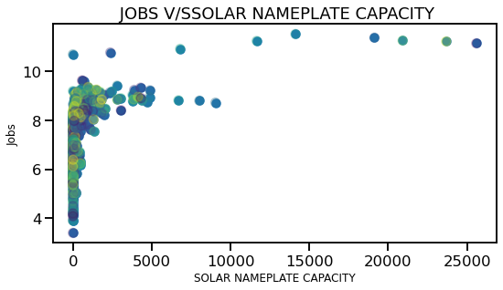

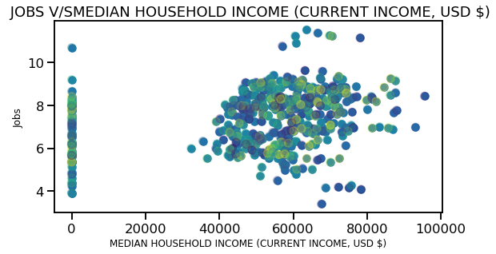

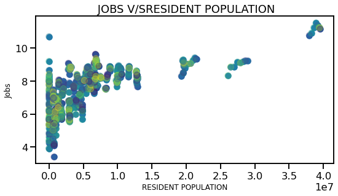

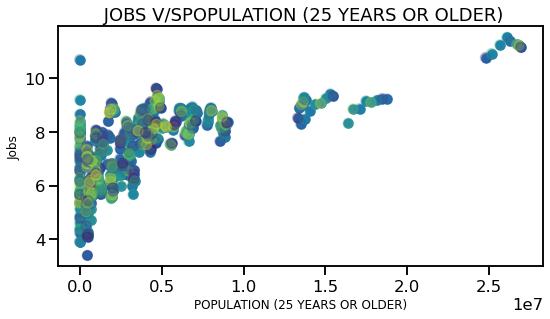

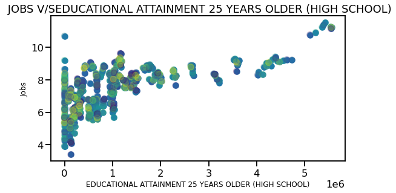

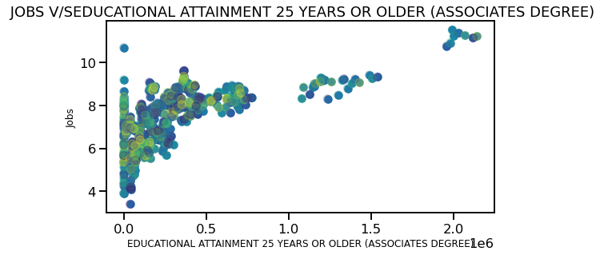

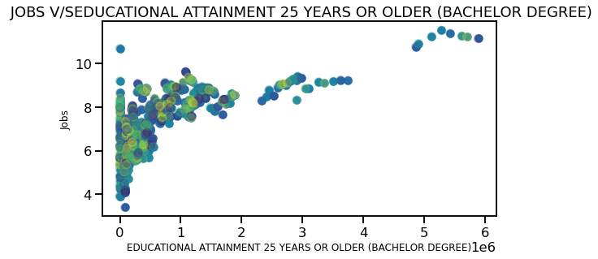

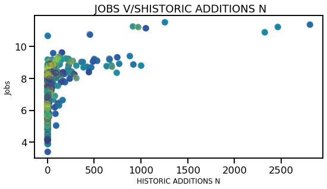

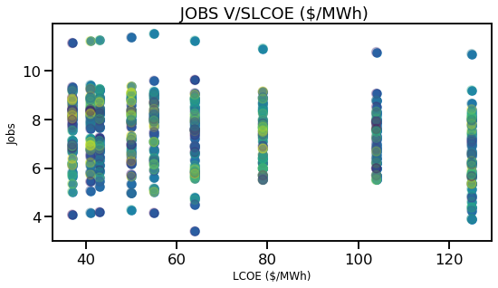

```python
#plotting some features with our output variable

features = ['SOLAR NAMEPLATE CAPACITY',
       'MEDIAN HOUSEHOLD INCOME (CURRENT INCOME, USD $)',
       'RESIDENT POPULATION', 'POPULATION (25 YEARS OR OLDER)',
       'EDUCATIONAL ATTAINMENT 25 YEARS OLDER (HIGH SCHOOL)',
       'EDUCATIONAL ATTAINMENT 25 YEARS OR OLDER (ASSOCIATES DEGREE)',
       'EDUCATIONAL ATTAINMENT 25 YEARS OR OLDER (BACHELOR DEGREE)',
       'HISTORIC ADDITIONS N', 'LCOE ($/MWh)' ]

for i in features:

    plt.figure(figsize=(40,15))
    plt.subplot(3, 4,4)

    x = solar[i]
    y = np.log(solar['JOBS'])

    plt.scatter(x,y)
    rng = np.random.RandomState(0)
    colors = rng.rand(len(solar[i]))
    plt.scatter(x, y, c=colors, s=100, alpha=0.3,
            cmap='viridis')
    #plt.colorbar()
    plt.title(" JOBS V/S"+ i)
    plt.xlabel(i,fontsize=12)
    plt.ylabel("Jobs",fontsize=12)
    plt.show()

plt.tight_layout()
plt.show()
```

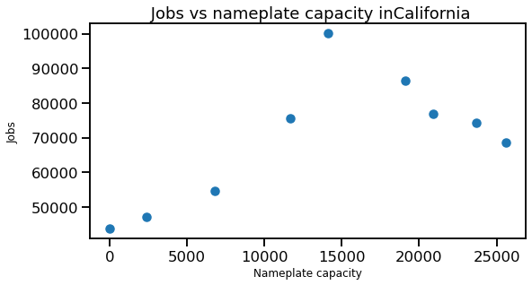

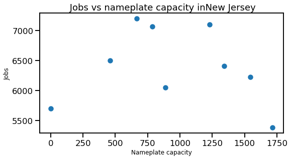

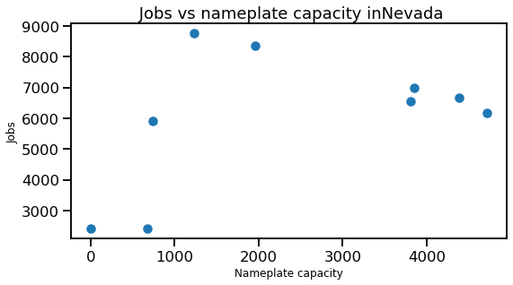

```python
st = ['California', 'New Jersey', 'Nevada' ]

for s in st:

    plt.figure(figsize=(40,15))
    plt.subplot(3, 4,4)

    x = solar.loc[solar['STATE']== s, 'SOLAR NAMEPLATE CAPACITY']
    y = solar.loc[solar['STATE']== s, 'JOBS']

    plt.scatter(x,y,)
    plt.title(" Jobs vs nameplate capacity in"+ s )
    plt.xlabel('Nameplate capacity',fontsize=12)
    plt.ylabel("Jobs",fontsize=12)
    plt.show()
```

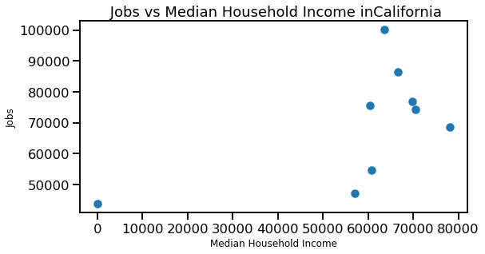

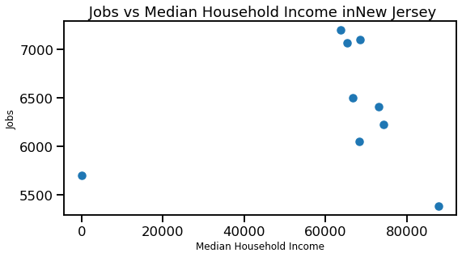

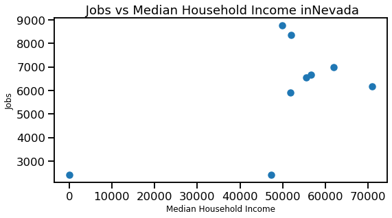

```python
st = ['California', 'New Jersey', 'Nevada' ]

for s in st:

    plt.figure(figsize=(40,15))
    plt.subplot(3, 4,4)

    x = solar.loc[solar['STATE']== s, 'MEDIAN HOUSEHOLD INCOME (CURRENT INCOME, USD $)']
    y = solar.loc[solar['STATE']== s, 'JOBS']

    plt.scatter(x,y,)
    plt.title(" Jobs vs Median Household Income in"+ s )
    plt.xlabel('Median Household Income',fontsize=12)
    plt.ylabel("Jobs",fontsize=12)
    plt.show()
```

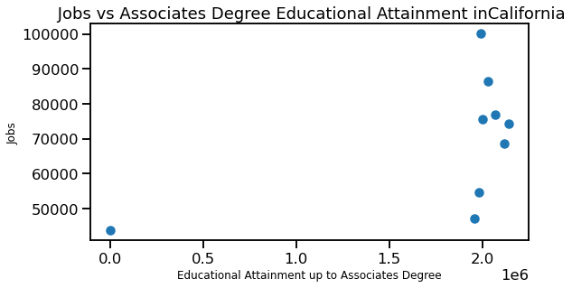

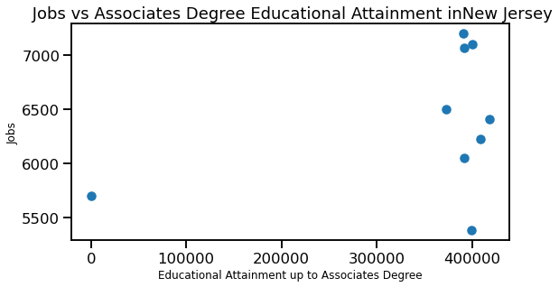

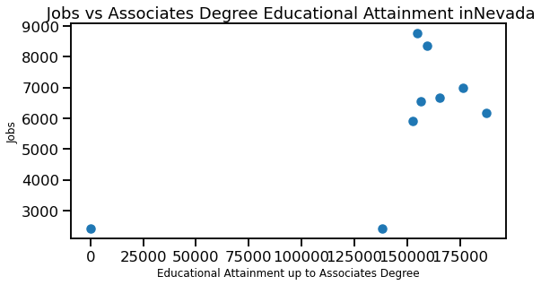

```python
st = ['California', 'New Jersey', 'Nevada' ]

for s in st:

    plt.figure(figsize=(40,15))
    plt.subplot(3, 4,4)

    x = solar.loc[solar['STATE']== s, 'EDUCATIONAL ATTAINMENT 25 YEARS OR OLDER (ASSOCIATES DEGREE)']
    y = solar.loc[solar['STATE']== s, 'JOBS']

    plt.scatter(x,y,)
    plt.title(" Jobs vs Associates Degree Educational Attainment in"+ s )
    plt.xlabel('Educational Attainment up to Associates Degree',fontsize=12)
    plt.ylabel("Jobs",fontsize=12)
    plt.show()
```

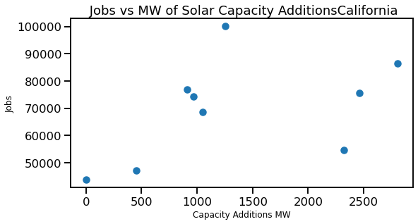

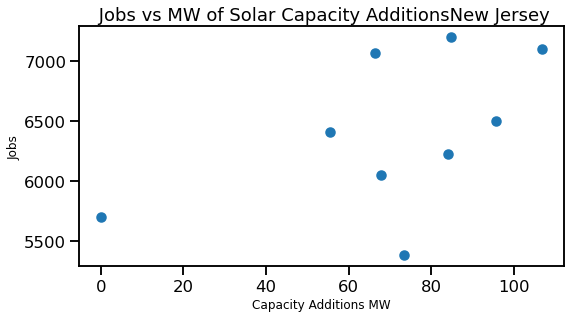

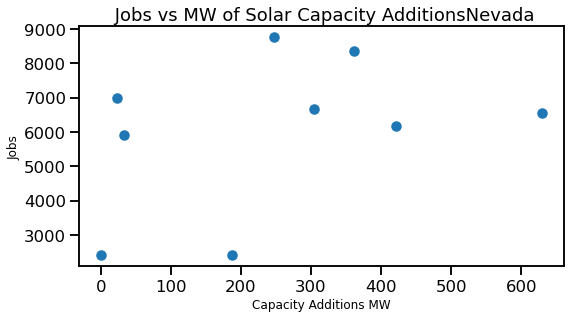

```python
st = ['California', 'New Jersey', 'Nevada' ]

for s in st:

    plt.figure(figsize=(40,15))
    plt.subplot(3, 4,4)

    x = solar.loc[solar['STATE']== s, 'HISTORIC ADDITIONS N']
    y = solar.loc[solar['STATE']== s, 'JOBS']

    plt.scatter(x,y,)
    plt.title(" Jobs vs MW of Solar Capacity Additions"+ s )
    plt.xlabel('Capacity Additions MW',fontsize=12)
    plt.ylabel("Jobs",fontsize=12)
    plt.show()
```

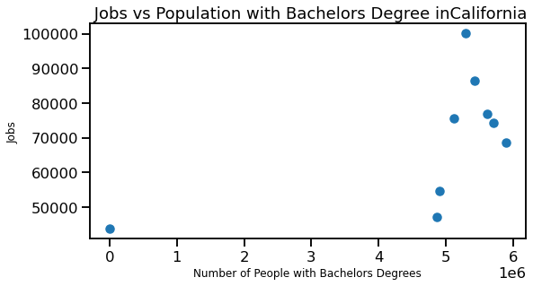

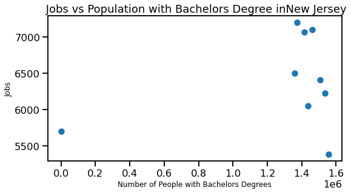

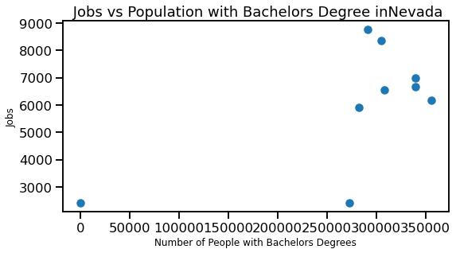

```python
st = ['California', 'New Jersey', 'Nevada' ]

for s in st:

    plt.figure(figsize=(40,15))
    plt.subplot(3, 4,4)

    x = solar.loc[solar['STATE']== s, 'EDUCATIONAL ATTAINMENT 25 YEARS OR OLDER (BACHELOR DEGREE)']
    y = solar.loc[solar['STATE']== s, 'JOBS']

    plt.scatter(x,y,)
    plt.title(" Jobs vs Population with Bachelors Degree in"+ s )
    plt.xlabel('Number of People with Bachelors Degrees',fontsize=12)
    plt.ylabel("Jobs", fontsize=12)
    plt.show()
```

We made our state variables into dummies so they could be properly considered by the model.

```python
solar_dummy = pd.get_dummies(solar)
solar_dummy
```

|  | JOBS | PREDICTION YEAR | SOLAR NAMEPLATE CAPACITY | MEDIAN HOUSEHOLD INCOME (CURRENT INCOME, USD $) | RESIDENT POPULATION | POPULATION (25 YEARS OR OLDER) | EDUCATIONAL ATTAINMENT 25 YEARS OLDER (HIGH SCHOOL) | EDUCATIONAL ATTAINMENT 25 YEARS OR OLDER (ASSOCIATES DEGREE) | EDUCATIONAL ATTAINMENT 25 YEARS OR OLDER (BACHELOR DEGREE) | HISTORIC ADDITIONS N | ... | STATE_South Dakota | STATE_Tennessee | STATE_Texas | STATE_Utah | STATE_Vermont | STATE_Virginia | STATE_Washington | STATE_West Virginia | STATE_Wisconsin | STATE_Wyoming |
| --- | --- | --- | --- | --- | --- | --- | --- | --- | --- | --- | --- | --- | --- | --- | --- | --- | --- | --- | --- | --- | --- |
| 0 | 210.000000 | 2012 | 0.0 | 0 | 0 | 0 | 0 | 0 | 0 | 0.0 | ... | 0 | 0 | 0 | 0 | 0 | 0 | 0 | 0 | 0 | 0 |
| 1 | 80.000000 | 2012 | 0.0 | 0 | 0 | 0 | 0 | 0 | 0 | 0.0 | ... | 0 | 0 | 0 | 0 | 0 | 0 | 0 | 0 | 0 | 0 |
| 2 | 9800.000000 | 2012 | 0.0 | 0 | 0 | 0 | 0 | 0 | 0 | 0.0 | ... | 0 | 0 | 0 | 0 | 0 | 0 | 0 | 0 | 0 | 0 |
| 3 | 130.000000 | 2012 | 0.0 | 0 | 0 | 0 | 0 | 0 | 0 | 0.0 | ... | 0 | 0 | 0 | 0 | 0 | 0 | 0 | 0 | 0 | 0 |
| 4 | 43700.000000 | 2012 | 0.0 | 0 | 0 | 0 | 0 | 0 | 0 | 0.0 | ... | 0 | 0 | 0 | 0 | 0 | 0 | 0 | 0 | 0 | 0 |
| ... | ... | ... | ... | ... | ... | ... | ... | ... | ... | ... | ... | ... | ... | ... | ... | ... | ... | ... | ... | ... | ... |
| 454 | 3564.782012 | 2020 | 39.4 | 82454 | 7614893 | 5290324 | 1167347 | 527524 | 1204728 | 0.5 | ... | 0 | 0 | 0 | 0 | 0 | 0 | 1 | 0 | 0 | 0 |
| 455 | 1069.129857 | 2020 | 13.8 | 93111 | 705749 | 505145 | 79881 | 16922 | 129825 | 7.8 | ... | 0 | 0 | 0 | 0 | 0 | 0 | 0 | 0 | 0 | 0 |
| 456 | 310.564091 | 2020 | 0.0 | 53706 | 1792147 | 1281086 | 515431 | 101267 | 161686 | 0.0 | ... | 0 | 0 | 0 | 0 | 0 | 0 | 0 | 1 | 0 | 0 |
| 457 | 2909.931294 | 2020 | 80.8 | 67355 | 5822434 | 4015285 | 1223392 | 438381 | 829878 | 20.3 | ... | 0 | 0 | 0 | 0 | 0 | 0 | 0 | 0 | 1 | 0 |
| 458 | 152.442312 | 2020 | 184.0 | 65134 | 578759 | 389847 | 117501 | 44034 | 73183 | 0.0 | ... | 0 | 0 | 0 | 0 | 0 | 0 | 0 | 0 | 0 | 1 |

459 rows × 69 columns

```python
jobs = "JOBS"
state = "STATE"
pred_year = "PREDICTION YEAR"
nameplate = "SOLAR NAMEPLATE CAPACITY"
year = 'YEAR_x'
income = "MEDIAN HOUSEHOLD INCOME (CURRENT INCOME, USD $)"
res_pop = "RESIDENT POPULATION"
twentyfive_pop = "POPULATION (25 YEARS OR OLDER)"
high_school = "EDUCATIONAL ATTAINMENT 25 YEARS OLDER (HIGH SCHOOL)"
associates = "EDUCATIONAL ATTAINMENT 25 YEARS OR OLDER (ASSOCIATES DEGREE)"
bachelor = "EDUCATIONAL ATTAINMENT 25 YEARS OR OLDER (BACHELOR DEGREE)"
additions_n = "HISTORIC ADDITIONS N"
additions_n1 = "PROYECTED ADD N+1"
additions_n2 = "PROYECTED ADD N+2"
additions_n3 = "PROYECTED ADD N+3"
additions_n4 = "PROYECTED ADD N+4"
additions_n5 = "PROYECTED ADD N+5"
additions_n6 = "PROYECTED ADD N+6"
lcoe = "LCOE ($/MWh)"

X_iloc = solar_dummy.iloc[:,1:]
X = X_iloc
y = np.log(solar_dummy[[jobs]])

#We took the log of the y values after consulting with Jess because there were so many 0s in our dataset and that was skewing our results.
#By taking the log we were able to produce a more normal distribution (Gaussian) of our y values.
```

```python
print(X.shape)
print(solar_dummy.shape)
print(y.shape)
```

```
(459, 68)
(459, 69)
(459, 1)
```

```python
X
```

|  | PREDICTION YEAR | SOLAR NAMEPLATE CAPACITY | MEDIAN HOUSEHOLD INCOME (CURRENT INCOME, USD $) | RESIDENT POPULATION | POPULATION (25 YEARS OR OLDER) | EDUCATIONAL ATTAINMENT 25 YEARS OLDER (HIGH SCHOOL) | EDUCATIONAL ATTAINMENT 25 YEARS OR OLDER (ASSOCIATES DEGREE) | EDUCATIONAL ATTAINMENT 25 YEARS OR OLDER (BACHELOR DEGREE) | HISTORIC ADDITIONS N | PROYECTED ADD N+1 | ... | STATE_South Dakota | STATE_Tennessee | STATE_Texas | STATE_Utah | STATE_Vermont | STATE_Virginia | STATE_Washington | STATE_West Virginia | STATE_Wisconsin | STATE_Wyoming |
| --- | --- | --- | --- | --- | --- | --- | --- | --- | --- | --- | --- | --- | --- | --- | --- | --- | --- | --- | --- | --- | --- |
| 0 | 2012 | 0.0 | 0 | 0 | 0 | 0 | 0 | 0 | 0.0 | 0.0 | ... | 0 | 0 | 0 | 0 | 0 | 0 | 0 | 0 | 0 | 0 |
| 1 | 2012 | 0.0 | 0 | 0 | 0 | 0 | 0 | 0 | 0.0 | 0.0 | ... | 0 | 0 | 0 | 0 | 0 | 0 | 0 | 0 | 0 | 0 |
| 2 | 2012 | 0.0 | 0 | 0 | 0 | 0 | 0 | 0 | 0.0 | 0.0 | ... | 0 | 0 | 0 | 0 | 0 | 0 | 0 | 0 | 0 | 0 |
| 3 | 2012 | 0.0 | 0 | 0 | 0 | 0 | 0 | 0 | 0.0 | 0.0 | ... | 0 | 0 | 0 | 0 | 0 | 0 | 0 | 0 | 0 | 0 |
| 4 | 2012 | 0.0 | 0 | 0 | 0 | 0 | 0 | 0 | 0.0 | 0.0 | ... | 0 | 0 | 0 | 0 | 0 | 0 | 0 | 0 | 0 | 0 |
| ... | ... | ... | ... | ... | ... | ... | ... | ... | ... | ... | ... | ... | ... | ... | ... | ... | ... | ... | ... | ... | ... |
| 454 | 2020 | 39.4 | 82454 | 7614893 | 5290324 | 1167347 | 527524 | 1204728 | 0.5 | 25.0 | ... | 0 | 0 | 0 | 0 | 0 | 0 | 1 | 0 | 0 | 0 |
| 455 | 2020 | 13.8 | 93111 | 705749 | 505145 | 79881 | 16922 | 129825 | 7.8 | 0.0 | ... | 0 | 0 | 0 | 0 | 0 | 0 | 0 | 0 | 0 | 0 |
| 456 | 2020 | 0.0 | 53706 | 1792147 | 1281086 | 515431 | 101267 | 161686 | 0.0 | 0.0 | ... | 0 | 0 | 0 | 0 | 0 | 0 | 0 | 1 | 0 | 0 |
| 457 | 2020 | 80.8 | 67355 | 5822434 | 4015285 | 1223392 | 438381 | 829878 | 20.3 | 307.0 | ... | 0 | 0 | 0 | 0 | 0 | 0 | 0 | 0 | 1 | 0 |
| 458 | 2020 | 184.0 | 65134 | 578759 | 389847 | 117501 | 44034 | 73183 | 0.0 | 0.0 | ... | 0 | 0 | 0 | 0 | 0 | 0 | 0 | 0 | 0 | 1 |

459 rows × 68 columns

```python
solar_dummy[jobs].astype(int)
```

```
0        210
1         80
2       9800
3        130
4      43700
       ...
454     3564
455     1069
456      310
457     2909
458      152
Name: JOBS, Length: 459, dtype: int64
```

**MODEL 1: OLS**

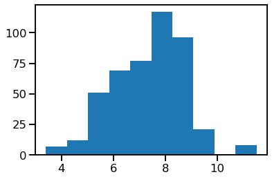

```python
plt.hist((y))
```

```python
def fit_OLS(X,y):
    X_const = sm.add_constant(X)
    ols_model = sm.OLS(y,X_const)
    results = ols_model.fit()
    return results.summary()
```

```python
fit_OLS(X,y)
```

OLS Regression Results

| Dep. Variable: | JOBS | R-squared: | 0.948 |
| --- | --- | --- | --- |
| Model: | OLS | Adj. R-squared: | 0.940 |
| Method: | Least Squares | F-statistic: | 111.1 |
| Date: | Mon, 13 Dec 2021 | Prob (F-statistic): | 9.68e-216 |
| Time: | 18:39:28 | Log-Likelihood: | -112.75 |
| No. Observations: | 459 | AIC: | 357.5 |
| Df Residuals: | 393 | BIC: | 630.0 |
| Df Model: | 65 |  |  |
| Covariance Type: | nonrobust |  |  |

|  | coef | std err | t | P>\|t\| | [0.025 | 0.975] |
| --- | --- | --- | --- | --- | --- | --- |
| const | 64.7512 | 39.291 | 1.648 | 0.100 | -12.496 | 141.999 |
| PREDICTION YEAR | -0.0290 | 0.020 | -1.465 | 0.144 | -0.068 | 0.010 |
| SOLAR NAMEPLATE CAPACITY | 8.494e-07 | 2.11e-05 | 0.040 | 0.968 | -4.06e-05 | 4.23e-05 |
| MEDIAN HOUSEHOLD INCOME (CURRENT INCOME, USD $) | 7.54e-06 | 1.73e-06 | 4.363 | 0.000 | 4.14e-06 | 1.09e-05 |
| RESIDENT POPULATION | 6.188e-07 | 2.12e-07 | 2.919 | 0.004 | 2.02e-07 | 1.04e-06 |
| POPULATION (25 YEARS OR OLDER) | -1.474e-06 | 4.73e-07 | -3.120 | 0.002 | -2.4e-06 | -5.45e-07 |
| EDUCATIONAL ATTAINMENT 25 YEARS OLDER (HIGH SCHOOL) | 4.709e-07 | 2.88e-07 | 1.634 | 0.103 | -9.57e-08 | 1.04e-06 |
| EDUCATIONAL ATTAINMENT 25 YEARS OR OLDER (ASSOCIATES DEGREE) | 3.487e-06 | 9.06e-07 | 3.850 | 0.000 | 1.71e-06 | 5.27e-06 |
| EDUCATIONAL ATTAINMENT 25 YEARS OR OLDER (BACHELOR DEGREE) | 6.979e-07 | 5.45e-07 | 1.281 | 0.201 | -3.73e-07 | 1.77e-06 |
| HISTORIC ADDITIONS N | 0.0002 | 0.000 | 1.795 | 0.073 | -2.14e-05 | 0.000 |
| PROYECTED ADD N+1 | 0.0002 | 7.68e-05 | 2.124 | 0.034 | 1.21e-05 | 0.000 |
| PROYECTED ADD N+2 | -4.629e-05 | 0.000 | -0.309 | 0.757 | -0.000 | 0.000 |
| PROYECTED ADD N+3 | 0.0002 | 0.000 | 0.762 | 0.446 | -0.000 | 0.001 |
| PROYECTED ADD N+4 | 0.0001 | 0.001 | 0.225 | 0.822 | -0.001 | 0.001 |
| PROYECTED ADD N+5 | 0.0020 | 0.001 | 1.674 | 0.095 | -0.000 | 0.004 |
| PROYECTED ADD N+6 | -2.972e-09 | 5.93e-10 | -5.010 | 0.000 | -4.14e-09 | -1.81e-09 |
| PROYECTED ADD N+7 | 7.942e-10 | 6.75e-10 | 1.176 | 0.240 | -5.34e-10 | 2.12e-09 |
| LCOE ($/MWh) | -0.0085 | 0.002 | -4.142 | 0.000 | -0.013 | -0.004 |
| STATE_Alabama | 0.1314 | 0.789 | 0.167 | 0.868 | -1.420 | 1.683 |
| STATE_Alaska | -1.7791 | 0.777 | -2.289 | 0.023 | -3.307 | -0.251 |
| STATE_Arizona | 2.8697 | 0.784 | 3.659 | 0.000 | 1.328 | 4.412 |
| STATE_Arkansas | -0.2031 | 0.787 | -0.258 | 0.797 | -1.751 | 1.345 |
| STATE_California | 5.2704 | 0.832 | 6.334 | 0.000 | 3.635 | 6.906 |
| STATE_Colorado | 2.3969 | 0.762 | 3.146 | 0.002 | 0.899 | 3.894 |
| STATE_Connecticut | 1.3251 | 0.777 | 1.705 | 0.089 | -0.203 | 2.853 |
| STATE_Delaware | 0.0256 | 0.776 | 0.033 | 0.974 | -1.500 | 1.551 |
| STATE_District of Columbia | 0.8123 | 0.780 | 1.041 | 0.298 | -0.721 | 2.346 |
| STATE_Florida | 2.7394 | 0.820 | 3.340 | 0.001 | 1.127 | 4.352 |
| STATE_Georgia | 1.9658 | 0.790 | 2.489 | 0.013 | 0.413 | 3.519 |
| STATE_Hawaii | 1.5481 | 0.773 | 2.002 | 0.046 | 0.028 | 3.068 |
| STATE_Idaho | 0.0429 | 0.773 | 0.056 | 0.956 | -1.477 | 1.563 |
| STATE_Illinois | 2.1825 | 0.782 | 2.791 | 0.006 | 0.645 | 3.720 |
| STATE_Indiana | 1.4103 | 0.791 | 1.784 | 0.075 | -0.144 | 2.965 |
| STATE_Iowa | 0.0680 | 0.770 | 0.088 | 0.930 | -1.446 | 1.582 |
| STATE_Kansas | 0.1566 | 0.772 | 0.203 | 0.839 | -1.361 | 1.674 |
| STATE_Kentucky | 0.9343 | 0.794 | 1.177 | 0.240 | -0.627 | 2.495 |
| STATE_Louisiana | 1.7563 | 0.798 | 2.201 | 0.028 | 0.188 | 3.325 |
| STATE_Maine | 0.1932 | 0.773 | 0.250 | 0.803 | -1.326 | 1.712 |
| STATE_Maryland | 2.2714 | 0.788 | 2.882 | 0.004 | 0.722 | 3.821 |
| STATE_Massachusetts | 3.1184 | 0.771 | 4.043 | 0.000 | 1.602 | 4.635 |
| STATE_Michigan | 1.9163 | 0.792 | 2.421 | 0.016 | 0.360 | 3.473 |
| STATE_Minnesota | 1.2145 | 0.759 | 1.599 | 0.111 | -0.279 | 2.707 |
| STATE_Mississippi | 0.3047 | 0.782 | 0.390 | 0.697 | -1.232 | 1.841 |
| STATE_Missouri | 1.7541 | 0.788 | 2.225 | 0.027 | 0.204 | 3.304 |
| STATE_Montana | -0.6507 | 0.772 | -0.843 | 0.400 | -2.168 | 0.866 |
| STATE_Nebraska | 0.3716 | 0.770 | 0.482 | 0.630 | -1.143 | 1.886 |
| STATE_Nevada | 2.5107 | 0.784 | 3.201 | 0.001 | 0.969 | 4.053 |
| STATE_New Hampshire | 0.5136 | 0.774 | 0.663 | 0.508 | -1.009 | 2.036 |
| STATE_New Jersey | 2.9096 | 0.787 | 3.697 | 0.000 | 1.362 | 4.457 |
| STATE_New Mexico | 1.5699 | 0.779 | 2.016 | 0.044 | 0.039 | 3.101 |
| STATE_New York | 3.0225 | 0.792 | 3.816 | 0.000 | 1.465 | 4.580 |
| STATE_North Carolina | 2.1542 | 0.776 | 2.776 | 0.006 | 0.629 | 3.680 |
| STATE_North Dakota | -0.9981 | 0.771 | -1.295 | 0.196 | -2.513 | 0.517 |
| STATE_Ohio | 2.4381 | 0.805 | 3.029 | 0.003 | 0.856 | 4.021 |
| STATE_Oklahoma | 0.3564 | 0.783 | 0.455 | 0.649 | -1.183 | 1.895 |
| STATE_Oregon | 2.0624 | 0.776 | 2.657 | 0.008 | 0.536 | 3.588 |
| STATE_Pennsylvania | 2.0881 | 0.813 | 2.569 | 0.011 | 0.490 | 3.686 |
| STATE_Rhode Island | 0.3951 | 0.775 | 0.510 | 0.610 | -1.128 | 1.918 |
| STATE_South Carolina | 1.2640 | 0.779 | 1.623 | 0.105 | -0.267 | 2.795 |
| STATE_South Dakota | -0.4082 | 0.771 | -0.529 | 0.597 | -1.924 | 1.108 |
| STATE_Tennessee | 2.3115 | 0.799 | 2.892 | 0.004 | 0.740 | 3.883 |
| STATE_Texas | 2.7976 | 0.849 | 3.297 | 0.001 | 1.129 | 4.466 |
| STATE_Utah | 1.3623 | 0.768 | 1.773 | 0.077 | -0.148 | 2.873 |
| STATE_Vermont | 0.8783 | 0.774 | 1.135 | 0.257 | -0.644 | 2.400 |
| STATE_Virginia | 1.8211 | 0.778 | 2.342 | 0.020 | 0.292 | 3.350 |
| STATE_Washington | 1.6204 | 0.765 | 2.117 | 0.035 | 0.116 | 3.125 |
| STATE_West Virginia | -0.2549 | 0.785 | -0.325 | 0.746 | -1.799 | 1.289 |
| STATE_Wisconsin | 1.3260 | 0.771 | 1.720 | 0.086 | -0.190 | 2.842 |
| STATE_Wyoming | -1.1359 | 0.774 | -1.468 | 0.143 | -2.657 | 0.386 |

| Omnibus: | 27.371 | Durbin-Watson: | 1.724 |
| --- | --- | --- | --- |
| Prob(Omnibus): | 0.000 | Jarque-Bera (JB): | 89.586 |
| Skew: | 0.081 | Prob(JB): | 3.52e-20 |
| Kurtosis: | 5.158 | Cond. No. | 8.96e+18 |

Notes:  
[1] Standard Errors assume that the covariance matrix of the errors is correctly specified.  
[2] The smallest eigenvalue is 6.9e-22. This might indicate that there are  
strong multicollinearity problems or that the design matrix is singular.

```python
from sklearn import datasets, linear_model
lm_solar = linear_model.LinearRegression()
fit_solar = lm_solar.fit(X,y)
```

```python
y_pred = fit_solar.predict(X)
```

```python
y_pred
```

[output not shown]

[output cut: 404 more lines]

```
       [ 8.38563622],
       [ 8.46380516],
       [ 6.76274858],
       [ 7.9444622 ],
       [ 5.99347609],
       [ 8.3670116 ],
       [ 9.71681479],
       [ 8.84308275],
       [ 7.26427691],
       [ 8.30271974],
       [ 8.21403025],
       [ 7.22069817],
       [ 5.90428875],
       [ 8.0809197 ],
       [ 5.22412366]])
```

```python
beta0_hat =  fit_solar.intercept_
betan_hat = fit_solar.coef_
print('beta0_hat:', beta0_hat)
print('betan_hat:', betan_hat)
```

```
beta0_hat: [66.02102221]
betan_hat: [[-2.90158577e-02  8.49391193e-07  7.53975594e-06  6.18830844e-07
  -1.47441518e-06  4.70868068e-07  3.48726284e-06  6.97947240e-07
   2.25354243e-04  1.63151102e-04 -4.62899399e-05  2.04854101e-04
   1.17983716e-04  2.00434108e-03  2.77938227e-09  7.80575604e-12
  -8.48452710e-03 -1.13820794e+00 -3.04872096e+00  1.60003721e+00
  -1.47273012e+00  4.00073263e+00  1.12722734e+00  5.54542022e-02
  -1.24398965e+00 -4.57349419e-01  1.46974389e+00  6.96120222e-01
   2.78477711e-01 -1.22670814e+00  9.12884642e-01  1.40689764e-01
  -1.20163985e+00 -1.11298927e+00 -3.35333984e-01  4.86636642e-01
  -1.07641708e+00  1.00179406e+00  1.84874395e+00  6.46644378e-01
  -5.51631017e-02 -9.64935404e-01  4.84447227e-01 -1.92037696e+00
  -8.97996931e-01  1.24108891e+00 -7.56079480e-01  1.64000629e+00
   3.00297302e-01  1.75283381e+00  8.84548674e-01 -2.26773045e+00
   1.16844628e+00 -9.13271517e-01  7.92724555e-01  8.18486424e-01
  -8.74534295e-01 -5.64330542e-03 -1.67781815e+00  1.04184863e+00
   1.52795313e+00  9.26613380e-02 -3.91361496e-01  5.51447921e-01
   3.50745596e-01 -1.52457973e+00  5.63648741e-02 -2.40551037e+00]]
```

**RESAMPLING FOR OLS: LOOCV, K-fold**

```python
from sklearn.model_selection import train_test_split
X_train, X_test, y_train, y_test = train_test_split(X, y, test_size=0.25, random_state=2021)
```

```python
lm = LinearRegression()
lm.fit(X_train, y_train)
predictions = lm.predict(X_test)

print('R^2: ', r2_score(y_test, predictions))
print('MSE: ', np.exp(mean_squared_error(y_test, predictions)))
```

```
R^2:  0.9081858563607635
MSE:  1.1659098362071314
```

```python
from sklearn.model_selection import LeaveOneOut
loo = LeaveOneOut()
loo.get_n_splits(X)
y_tests = []
y_predictions = []

for train, test in loo.split(X):
    Xr_train, Xr_test = np.array(X)[train], np.array(X)[test]
    yr_train, yr_test = np.array(y)[train], np.array(y)[test]

    lr = LinearRegression()
    lr.fit(Xr_train, yr_train)
    yr_pred = lr.predict(Xr_test)

    y_tests.append(yr_test[0][0])
    y_predictions.append(yr_pred[0][0])

r2_loo = r2_score(y_tests, y_predictions)
MSE_loo = np.exp(mean_squared_error(yr_test, yr_pred))
print("R^2 after LOOCV: ", r2_loo)
print("OLS MSE after LOOCV: ", np.exp(MSE_loo))
```

```
R^2 after LOOCV:  0.9265035318641208
OLS MSE after LOOCV:  2.863096565610422
```

```python
from sklearn.model_selection import KFold
kf = KFold(n_splits = 4, shuffle = True, random_state = 1)

fold = 1
for t_index, v_index in kf.split(X):
    print("Fold", fold)
    print("Train:", t_index, "Test:", v_index, '\n')
    fold+=1
```

[output not shown]

[output cut: 96 more lines]

```python
kf = KFold(n_splits = 4, shuffle = True, random_state = 1)

fold_mse = []

for t_index, v_index in kf.split(X):
    X_fold_train = np.array(X)[t_index]
    y_fold_train = np.array(y)[t_index]
    X_fold_val = np.array(X)[v_index]
    y_fold_val = np.array(y)[v_index]
    lm = LinearRegression()
    lm.fit(X_fold_train, y_fold_train)
    y_pred = lm.predict(X_fold_val)

    MSE_F = mean_squared_error(y_fold_val, y_pred)
    fold_mse.append(MSE_F)

print(fold_mse)
```

```
[0.12573645365591438, 0.1276868084756609, 0.1478708576411813, 0.17996043340897908]
```

**MODELS 2 AND 3: RIDGE AND LASSO MODELS**

```python
from sklearn.preprocessing import StandardScaler

scaler = StandardScaler() # Initialize the StandardScaler
scaler.fit(X) # Fit the standard scaler for each feature
print(scaler.mean_) # Print the mean value of each feature

solar_standard = scaler.transform(X)
solar_standard
```

```
[2.01600000e+03 6.68593028e+02 5.26119630e+04 5.60264651e+06
 3.78561629e+06 1.03685673e+06 3.14670972e+05 7.27722325e+05
 7.90477124e+01 7.78259259e+01 4.01631808e+01 1.56479303e+01
 4.22374728e+00 6.53594771e-01 0.00000000e+00 0.00000000e+00
 6.64444444e+01 1.96078431e-02 1.96078431e-02 1.96078431e-02
 1.96078431e-02 1.96078431e-02 1.96078431e-02 1.96078431e-02
 1.96078431e-02 1.96078431e-02 1.96078431e-02 1.96078431e-02
 1.96078431e-02 1.96078431e-02 1.96078431e-02 1.96078431e-02
 1.96078431e-02 1.96078431e-02 1.96078431e-02 1.96078431e-02
 1.96078431e-02 1.96078431e-02 1.96078431e-02 1.96078431e-02
 1.96078431e-02 1.96078431e-02 1.96078431e-02 1.96078431e-02
 1.96078431e-02 1.96078431e-02 1.96078431e-02 1.96078431e-02
 1.96078431e-02 1.96078431e-02 1.96078431e-02 1.96078431e-02
 1.96078431e-02 1.96078431e-02 1.96078431e-02 1.96078431e-02
 1.96078431e-02 1.96078431e-02 1.96078431e-02 1.96078431e-02
 1.96078431e-02 1.96078431e-02 1.96078431e-02 1.96078431e-02
 1.96078431e-02 1.96078431e-02 1.96078431e-02 1.96078431e-02]
```

```
array([[-1.54919334, -0.27301659, -2.47049899, ..., -0.14142136,
        -0.14142136, -0.14142136],
       [-1.54919334, -0.27301659, -2.47049899, ..., -0.14142136,
        -0.14142136, -0.14142136],
       [-1.54919334, -0.27301659, -2.47049899, ..., -0.14142136,
        -0.14142136, -0.14142136],
       ...,
       [ 1.54919334, -0.27301659,  0.05137268, ...,  7.07106781,
        -0.14142136, -0.14142136],
       [ 1.54919334, -0.24002232,  0.69228852, ..., -0.14142136,
         7.07106781, -0.14142136],
       [ 1.54919334, -0.19788112,  0.58799707, ..., -0.14142136,
        -0.14142136,  7.07106781]])
```

```python
from sklearn.model_selection import train_test_split

scaler = StandardScaler()
scaler.fit(X)
X_stnd = scaler.transform(X)
```

```python
print(X_train.shape, y_train.shape, X_test.shape, y_test.shape)
```

```
(344, 68) (344, 1) (115, 68) (115, 1)
```

```python
lm = LinearRegression()
lm.fit(X_train, y_train)
lm_coefficients = lm.coef_

print(lm_coefficients)
```

```
[[-1.55768951e-02  4.47281974e-06  7.88279056e-06  5.59080646e-07
  -1.37938944e-06  7.93111152e-07  3.04243077e-06  4.52893044e-07
   5.66964532e-04  1.02170476e-04 -3.27317177e-04  3.99025315e-04
   7.24280780e-06  2.19795222e-03  7.38251960e-11 -2.55484522e-12
  -7.77024787e-03 -1.18338309e+00 -3.12184527e+00  1.43670829e+00
  -1.43625421e+00  4.22036397e+00  1.27232863e+00  8.16061086e-02
  -1.20691216e+00 -4.01935930e-01  1.22296000e+00  7.13854072e-01
   4.36500789e-01 -1.19231957e+00  9.54827300e-01  1.40405886e-01
  -1.06782210e+00 -1.19399794e+00 -3.69240254e-01  4.17924839e-01
  -1.03176388e+00  1.02214491e+00  1.88680853e+00  6.53395230e-01
   5.82418769e-02 -1.03612019e+00  5.04581741e-01 -1.99023117e+00
  -8.26542235e-01  1.14272699e+00 -8.06187989e-01  1.70345025e+00
   3.41219281e-01  1.72968358e+00  7.66753104e-01 -2.19035617e+00
   9.39562456e-01 -8.81914884e-01  8.08988607e-01  3.50156242e-01
  -7.68657262e-01  6.92726137e-03 -1.64846711e+00  9.08726277e-01
   1.54062647e+00  1.40123048e-01 -3.88204266e-01  6.26385273e-01
   4.95360426e-01 -1.56930489e+00  1.11645407e-01 -2.32352628e+00]]
```

```python
ridge = Ridge(alpha=1)
ridge.fit(X_train, y_train)
ridge_coefficients = ridge.coef_

print(ridge_coefficients)
```

```
[[ 5.54454208e-03 -1.20974016e-05  2.83371751e-06  2.61232831e-07
  -9.19618120e-07  9.16496069e-07  1.84122263e-06  1.27794990e-06
   8.10403976e-04  7.99187829e-06 -4.97743596e-04  3.97267513e-04
  -9.51634541e-05  2.91361749e-03  0.00000000e+00  0.00000000e+00
  -4.71206600e-03 -9.25576543e-01 -2.34767336e+00  1.30390909e+00
  -1.09315797e+00  2.02174763e+00  1.07443596e+00  1.78207969e-01
  -7.48334789e-01 -1.09829533e-02 -1.58810140e-02  3.78409373e-01
   6.89124484e-01 -7.54476871e-01  3.73714905e-01  1.87342128e-01
  -6.84933963e-01 -7.44181256e-01 -1.85697208e-01  4.30096658e-01
  -6.51870788e-01  8.72717817e-01  1.50432268e+00  4.70979809e-01
   1.27481308e-01 -6.71010681e-01  3.99797368e-01 -1.44567146e+00
  -4.40244599e-01  1.19540538e+00 -3.40406845e-01  1.03966750e+00
   5.49338849e-01  5.71897992e-01  4.85492825e-01 -1.59307080e+00
   4.95528735e-01 -5.87116917e-01  8.19164365e-01 -2.72199143e-01
  -3.77049726e-01  1.21221881e-01 -1.14373257e+00  7.19132369e-01
   4.86476632e-01  4.58616032e-01 -2.95697639e-02  3.68119226e-01
   3.89520830e-01 -1.18131824e+00  1.76565128e-01 -1.64427746e+00]]
```

```python
lasso = Lasso(alpha=1)
lasso.fit(X_train, y_train)
lasso_coefficients = lasso.coef_
print(lasso_coefficients)
```

```
[ 0.00000000e+00  1.85867795e-05  5.08571650e-06 -1.92230459e-07
 -2.01114477e-07  1.00416103e-06 -1.28395205e-06  2.62328274e-06
  1.57117993e-03 -2.56269377e-04 -9.87278618e-04  4.24507880e-04
 -0.00000000e+00  2.15839458e-03  0.00000000e+00  0.00000000e+00
 -0.00000000e+00 -0.00000000e+00 -0.00000000e+00  0.00000000e+00
 -0.00000000e+00  0.00000000e+00  0.00000000e+00  0.00000000e+00
 -0.00000000e+00  0.00000000e+00 -0.00000000e+00  0.00000000e+00
  0.00000000e+00 -0.00000000e+00 -0.00000000e+00  0.00000000e+00
 -0.00000000e+00 -0.00000000e+00  0.00000000e+00  0.00000000e+00
 -0.00000000e+00  0.00000000e+00  0.00000000e+00  0.00000000e+00
  0.00000000e+00 -0.00000000e+00  0.00000000e+00 -0.00000000e+00
 -0.00000000e+00  0.00000000e+00 -0.00000000e+00  0.00000000e+00
  0.00000000e+00 -0.00000000e+00  0.00000000e+00 -0.00000000e+00
  0.00000000e+00 -0.00000000e+00  0.00000000e+00 -0.00000000e+00
 -0.00000000e+00  0.00000000e+00 -0.00000000e+00  0.00000000e+00
 -0.00000000e+00  0.00000000e+00  0.00000000e+00  0.00000000e+00
  0.00000000e+00 -0.00000000e+00  0.00000000e+00 -0.00000000e+00]
```

```python
def fit_model(SKL_model, X_train, X_test, y_train, y_test, alpha = 1):


    if SKL_model==LinearRegression():
        model != SKL_model()
        model.fit(X_train, y_train)
        model.coefficients = model.coef_
        y_pred = model.predict(X_test)
    else:
        model = SKL_model(alpha)
        model.fit(X_train, y_train)
        model.coefficients = model.coef_
        y_pred = model.predict(X_test)


    mse = mean_squared_error(y_test, y_pred)
    coef = model.coef_.flatten()
    return mse, coef
```

```python
Models = [LinearRegression, Ridge, Lasso]

mse_all = np.full(len(Models),np.nan)

coef_all = np.full((X_train.shape[1], len(Models)),np.nan)

for m in range(len(Models)):
    mse_all[m], coef_all[:,m] = fit_model(Models[m], X_train, X_test, y_train, y_test, alpha=1)

print (mse_all)# Replace the ellipses with your code
```

```
[0.15350176 0.21426667 0.94738934]
```

```python
from sklearn.linear_model import RidgeCV
alphas_ridge = [0.01, 0.02, 0.03, 0.04, 0.05, 0.06, 0.07, 0.08, 0.09, 0.1] # create an array or list of alpha values to test in Ridge regression
alphas_lasso = [.001, .002, .003, .004, .01, .0125, .02]

kf = KFold(n_splits = 10, shuffle = True, random_state = 8) # get KFold cross-validation selector object
ridgecv = RidgeCV(cv = kf, alphas= alphas_ridge) # pass CV object and list of alphas to RidgeCV()
ridgecv.fit(X_train, y_train) # fit RidgeCV model on training data

ridge_alpha_opt = ridgecv.alpha_ # get optimal alpha value
print("optimal alpha:", ridge_alpha_opt)

y_pred_ridgecv = ridgecv.predict(X_test) # get test predictions using RidgeCV model

ridge_cv_mse = mean_squared_error(y_test, y_pred_ridgecv) # get MSE of RidgeCV model
print("Test MSE with cross-validated Ridge:", ridge_cv_mse)
```

```
optimal alpha: 0.02
Test MSE with cross-validated Ridge: 0.15517892673438746
```

```python
ridge_cv_r2 = r2_score(y_test, y_pred_ridgecv)
print("Test R2 with cross-validated Lasso:", ridge_cv_r2)
print("Test MSE with cross-validated Ridge:", np.exp(ridge_cv_mse))
```

```
Test R2 with cross-validated Lasso: 0.9071826896252241
Test MSE with cross-validated Ridge: 1.1678669050232562
```

```python
from sklearn.linear_model import LassoCV

kf = KFold(n_splits = 10, shuffle = True, random_state = 8) # get KFold cross-validation selector object
lassocv = LassoCV(cv = kf, alphas = alphas_lasso) # pass CV object and list of alphas to LassoCV()
lassocv.fit(X_train, y_train) # fit RidgeCV model on training data

lasso_alpha_opt = lassocv.alpha_ # get optimal alpha value
print("optimal alpha:", lasso_alpha_opt)

y_pred_lassocv = lassocv.predict(X_test) # get test predictions using RidgeCV model

lasso_cv_mse = mean_squared_error(y_test, y_pred_lassocv) # get MSE of LassoCV model
print("Test MSE with cross-validated Lasso:", lasso_cv_mse)
```

```
optimal alpha: 0.001
Test MSE with cross-validated Lasso: 0.1794872372760147
```

```python
lasso_cv_r2 = r2_score(y_test, y_pred_lassocv)
print("Test R2 with cross-validated Lasso:", lasso_cv_r2)
print("Test MSE with cross-validated Lasso:", np.exp(lasso_cv_mse))
```

```
Test R2 with cross-validated Lasso: 0.8926431380784439
Test MSE with cross-validated Lasso: 1.196603632048149
```

**MODEL 4: DECISION TREE**

```python
from sklearn.tree import DecisionTreeClassifier
from sklearn.tree import DecisionTreeRegressor
from sklearn.model_selection import cross_val_score
from sklearn import tree
```

```python
# make the train/validation split
X_train, X_val, y_train, y_val = train_test_split(X, y, random_state = 2021, test_size = 0.25)

first_tree = DecisionTreeRegressor(random_state=2021)
first_tree.fit(X_train, y_train)

print("Number of features: {}".format(first_tree.tree_.n_features))
print("Number of nodes (internal and terminal): {}".format(first_tree.tree_.node_count), "\n")

train_score = first_tree.score(X_train, y_train)
val_score = first_tree.score(X_val, y_val)
test_score = first_tree.score(X_test, y_test)

print('Train Score: ', train_score)
print('Validation Score: ', val_score)
print('Test Score', test_score)
```

[output not shown]

```python
import graphviz
print(tree.export_graphviz(first_tree, feature_names=X.columns))
```

[output not shown]

```python
feature_importance = pd.DataFrame({'Feature': X.columns, 'Importance': first_tree.feature_importances_}) # get the importance of each feature
feature_importance
```

[output not shown]

```python
def importance_plot(tree):
    # YOUR CODE HERE
    feature_importance = pd.DataFrame({'Feature': X.columns, 'Importance': first_tree.feature_importances_}) # get the importance of each feature

    #calculate the relative feature importances
    relative_importance = ((feature_importance['Importance'])/0.58004)*100

    # Save to a dataframe with two columns: One holding the names of the features,
    # and one holding the associated relative importance of each feature.
    feat_df = pd.DataFrame({'feature':X_train.columns, 'importance':relative_importance})

    # Sort feat_df in order of importance
    feat_df = feat_df.sort_values(by='importance', ascending=True)

    plt.figure(figsize=(20, 50))

    # Create a bar chart. The widths of the bars should correspond to the importances,
    # and y should correspond to the names of the features.
    plt.barh(width= feat_df['importance'], y=feat_df['feature'])
    plt.xlabel('Relative feature importance');
```

```python
importance_plot(first_tree)
```

[output not shown]

```python
tuned_tree = DecisionTreeRegressor(max_leaf_nodes=20, max_features=17, random_state=2021)
tuned_tree.fit(X_train, y_train)

print("Number of features: {}".format(tuned_tree.tree_.n_features))
print("Number of nodes (leaves): {}".format(tuned_tree.tree_.node_count),"\n")

tuned_train_score = tuned_tree.score(X_train, y_train)
tuned_val_score = tuned_tree.score(X_val, y_val)
tuned_test_score = tuned_tree.score(X_test, y_test)

print('Train Score: ', tuned_train_score)
print('Validation Score: ', tuned_val_score)
print('Test Score', tuned_test_score)
```

[output not shown]

```python
from sklearn.model_selection import RandomizedSearchCV
from scipy.stats import randint

param_dist = {'max_leaf_nodes': randint(3, 100),
              'max_features': randint(2, 26),}

rnd_search = RandomizedSearchCV(tuned_tree, param_distributions=param_dist,
                                cv=5, n_iter=50, random_state = 2021)
rnd_search.fit(X_train, y_train)
```

```python
print(rnd_search.best_score_) # This is cross validation error from the training data set.
print(rnd_search.best_params_)
```

[output not shown]

```python
tuned_tree.set_params(max_features=24, max_leaf_nodes=47)
tuned_tree.fit(X_train, y_train)

tuned_train_score = tuned_tree.score(X_train, y_train)
tuned_val_score = tuned_tree.score(X_val, y_val)
tuned_test_score = tuned_tree.score(X_test, y_test)

print('Train Score: ', tuned_train_score)
print('Validation Score: ', tuned_val_score)
print('Test Score:', tuned_test_score)
```

[output not shown]

```python
importance_plot(tuned_tree)
```

[output not shown]

**MODEL 5: ENSEMBLE METHODS**

```python
from sklearn.ensemble import BaggingClassifier
from sklearn.ensemble import BaggingRegressor
```

```python
bag_tree = BaggingRegressor(n_estimators=150, random_state=2021, max_features = 17).fit(X_train, y_train)

bag_train_score = bag_tree.score(X_train, y_train)
bag_val_score = bag_tree.score(X_val, y_val)
bag_test_score = bag_tree.score(X_test, y_test)

print('Train Score: ', bag_train_score)
print('Validation Score: ', bag_val_score)
print('Test Score:', bag_test_score)
```

[output not shown]

```python
from sklearn.ensemble import RandomForestClassifier
from sklearn.ensemble import RandomForestRegressor
rf_tree = RandomForestRegressor(n_estimators=150, random_state=2021).fit(X_train, y_train)


rf_train_score = rf_tree.score(X_train, y_train)
rf_val_score = rf_tree.score(X_val, y_val)
rf_test_score = rf_tree.score(X_test, y_test)


print('Train Score: ', rf_train_score)
print('Validation Score: ', rf_val_score)
print('Test Score:', rf_test_score)
```

[output not shown]

```python
from sklearn.ensemble import GradientBoostingRegressor
gb_tree = GradientBoostingRegressor(n_estimators=150, random_state=2021).fit(X_train, y_train)


gb_train_score = gb_tree.score(X_train, y_train)
gb_val_score = gb_tree.score(X_val, y_val)
gb_test_score = gb_tree.score(X_test, y_test)

print('Train Score: ', gb_train_score)
print('Validation Score: ', gb_val_score)
print('Test Score:', gb_test_score)
```

[output not shown]

```python
importance_plot(gb_tree)
```

[output not shown]

```python
print('OLS R^2: ', r2_score(y_test, predictions))
print('OLS MSE: ', np.exp(mean_squared_error(y_test, predictions)))
print("OLS R^2 after LOOCV: ", r2_loo)
print("OLS MSE after LOOCV: ", np.exp(MSE_loo))
print("OLS MSE after k-fold CV: ", fold_mse)
print("Test R2 with cross-validated Ridge:", ridge_cv_r2)
print("Test MSE with cross-validated Ridge:", np.exp(ridge_cv_mse))
print("Test R2 with cross-validated Lasso:", lasso_cv_r2)
print("Test MSE with cross-validated Lasso:", np.exp(lasso_cv_mse))
print('Tuned Test Score', tuned_test_score)
print('GB Test Score:', gb_test_score)
print('RF Test Score:', rf_test_score)
print('Bagging Test Score:', bag_test_score)
```

[output not shown]

**PREDICTION**

```python
solar_2021 = pd.read_csv('2021 Solar.csv')
```

```python
solar_2021
```

[output not shown]

```python
X
```

[output not shown]

```python
best_ridge = Ridge(alpha=0.02)
best_ridge.fit(X, y)
```

[output not shown]

```python
solar_2021_dummy = pd.get_dummies(solar_2021)
```

```python
solar_2021_dummy
```

[output not shown]

```python
X_2021 = solar_2021_dummy.iloc[:,1:]
y_2021 = best_ridge.predict(X_2021)
```

```python
# shows the inputs and predicted outputs
print('X=%s, Predicted=%s' % (X_2021, y_2021))
```

[output not shown]

```python
y_predict = np.exp(y_2021)
y_predict
```

[output not shown]

```python
solar_2022 = pd.read_csv('2022 Solar.csv')
```

```python
solar_2022
```

[output not shown]

```python
solar_2022_dummy = pd.get_dummies(solar_2022, columns=['STATE'])
```

```python
solar_2022_dummy
```

[output not shown]

```python
X_2022 = solar_2022_dummy.iloc[:,1:]
y_2022 = best_ridge.predict(X_2022)
```

```python
print('X=%s, Predicted=%s' % (X_2022, y_2022))
```

[output not shown]

```python
y_predict_22 = np.exp(y_2022)
y_2022_predict = pd.DataFrame(y_predict_22)
y_predict_22
```

[output not shown]

```python
y_2021_predict = pd.DataFrame(y_predict)
y_2021_predict
```

[output not shown]

```python
y_2022_predict = pd.DataFrame(y_predict_22)
y_2022_predict
```

[output not shown]

```python
state = solar_2021[['STATE']]
state_22 = solar_2022[['STATE']]
```

```python
y_pred_df = pd.DataFrame(y_predict, index=X_2021.index)
y_results_21 = pd.concat([X_2021, y_pred_df], axis=1)
y_results_21
y_results_21['PREDICTED JOBS'] = y_results_21[0]
y_results_21
```

[output not shown]

```python
y_results_21_final = y_results_21[['SOLAR NAMEPLATE CAPACITY','PREDICTED JOBS']]
y_results_21_final['STATE'] = state
y_results_21_final
```

[output not shown]

```python
y_pred_df_22 = pd.DataFrame(y_predict_22, index=X_2022.index)
y_results_22 = pd.concat([X_2022, y_pred_df_22], axis=1)
y_results_22
y_results_22['PREDICTED JOBS'] = y_results_22[0]
y_results_22
```

[output not shown]

```python
y_results_22_final = y_results_22[['SOLAR NAMEPLATE CAPACITY','PREDICTED JOBS']]
y_results_22_final['STATE'] = state_22
y_results_22_final
```

[output not shown]

```python
print(y_results_21_final['PREDICTED JOBS'].min())
print(y_results_21_final['PREDICTED JOBS'].max())
print(y_results_22_final['PREDICTED JOBS'].min())
print(y_results_22_final['PREDICTED JOBS'].max())
```

[output not shown]

```python
#2021 Prediction Visualization

plt.figure(figsize=(100,50))
plt.subplot(3, 4,4)

x = y_results_21_final['STATE']
y = y_results_21_final['PREDICTED JOBS']
plt.bar(x,y)

plt.title(" PREDICTED SOLAR JOBS IN 2021 BY STATE ")
plt.xlabel('State',fontsize=20)
plt.xticks(rotation=90)
plt.ylabel("Jobs",fontsize=20)
plt.show()

plt.tight_layout()
plt.show()
```

[output not shown]

```python
#2022 Prediction Visualization

plt.figure(figsize=(100,50))
plt.subplot(3, 4,4)

x = y_results_22_final['STATE']
y = y_results_22_final['PREDICTED JOBS']
plt.bar(x,y, color ='maroon')

plt.title(" PREDICTED SOLAR JOBS IN 2022 BY STATE ")
plt.xlabel('State',fontsize=20)
plt.xticks(rotation=90)
plt.ylabel("Jobs",fontsize=20)
plt.show()

plt.tight_layout()
plt.show()
```

[output not shown]

```python
#Combined Visualization Plot

plt.figure(figsize=(200,75))
plt.subplot(3, 4, 4)


x = y_results_21_final['STATE']
y1 = y_results_21_final['PREDICTED JOBS']
y2 = y_results_22_final['PREDICTED JOBS']
x_axis = np.arange(len(x))

plt.bar(x_axis - 0.1,y1,width=0.3, alpha=1, label= "2021")
plt.bar(x_axis + 0.1,y2,width=0.3, alpha=1, label= "2022")
#plt.bar(x,y2, alpha=1, label= '2022')


plt.title(" PREDICTED SOLAR JOBS BY STATE ", fontsize=30)
plt.xlabel('State',fontsize=35)
plt.xticks(x_axis,x,fontsize=35,  rotation=90)
#plt.tick_params(axis='x', which='major', labelsize=3)
plt.tight_layout()


plt.ylabel("Jobs", fontsize=35)
plt.yticks(fontsize=30)
plt.legend(fontsize=50)
plt.show()
```

[output not shown]